# Season report: 4545 Season 24

### Openings - tables

#### Popular openings

All openings played in the season, excluding variations.

| Rank | Opening | Games | White % | 1-0 % | Draw % | 0-1 % | Mean Eval | Avg Rating |
| --- | --- | --- | --- | --- | --- | --- | --- | --- |
| 1 | Sicilian Defense | 238 | 59.453781512605 | 51.6806722689076 | 15.546218487395 | 32.7731092436975 | 0.487198275862069 | 1899.52941176471 |
| 2 | Caro-Kann Defense | 96 | 55.7291666666667 | 45.8333333333333 | 19.7916666666667 | 34.375 | 1.15329787234043 | 1861.53125 |
| 3 | French Defense | 80 | 57.5 | 48.75 | 17.5 | 33.75 | 0.640641025641026 | 1906.00625 |
| 4 | Italian Game | 70 | 51.4285714285714 | 45.7142857142857 | 11.4285714285714 | 42.8571428571429 | 0.34 | 1862.57142857143 |
| 5 | Queen's Gambit Declined | 65 | 53.0769230769231 | 47.6923076923077 | 10.7692307692308 | 41.5384615384615 | 0.905076923076923 | 1852.07692307692 |
| 6 | English Opening | 64 | 56.25 | 46.875 | 18.75 | 34.375 | 0.515593220338983 | 1875.234375 |
| 7 | Queen's Pawn Game | 56 | 43.75 | 39.2857142857143 | 8.92857142857143 | 51.7857142857143 | 0.0457407407407407 | 1881.63392857143 |
| 8 | Slav Defense | 44 | 67.0454545454545 | 61.3636363636364 | 11.3636363636364 | 27.2727272727273 | 0.939047619047619 | 1822.43181818182 |
| 9 | Ruy Lopez | 42 | 58.3333333333333 | 52.3809523809524 | 11.9047619047619 | 35.7142857142857 | 0.818780487804878 | 1921.05952380952 |
| 10 | Scandinavian Defense | 39 | 43.5897435897436 | 35.8974358974359 | 15.3846153846154 | 48.7179487179487 | 0.147777777777778 | 1802.37179487179 |

[output cut: 54 more lines]

#### Popular variations

All openings played in the season, including variations.

| Rank | Opening | Games | White % | 1-0 % | Draw % | 0-1 % | Mean Eval | Avg Rating |
| --- | --- | --- | --- | --- | --- | --- | --- | --- |
| 1 | Scandinavian Defense: Mieses-Kotroc Variation | 19 | 50 | 42.1052631578947 | 15.7894736842105 | 42.1052631578947 | 1.51470588235294 | 1800.34210526316 |
| 2 | Queen's Gambit Declined: Exchange Variation, Positional Variation | 16 | 40.625 | 37.5 | 6.25 | 56.25 | 1.226875 | 1821.5625 |
| 3 | Caro-Kann Defense: Advance Variation, Short Variation | 15 | 63.3333333333333 | 60 | 6.66666666666667 | 33.3333333333333 | 1.78666666666667 | 1803.5 |
| 3 | Italian Game: Classical Variation, Giuoco Pianissimo | 15 | 46.6666666666667 | 40 | 13.3333333333333 | 46.6666666666667 | 0.431333333333333 | 1816.56666666667 |
| 3 | Rapport-Jobava System | 15 | 66.6666666666667 | 53.3333333333333 | 26.6666666666667 | 20 | 2.42214285714286 | 1819.8 |
| 3 | Sicilian Defense: Closed | 15 | 60 | 53.3333333333333 | 13.3333333333333 | 33.3333333333333 | 1.35928571428571 | 1933.76666666667 |
| 4 | Indian Defense | 14 | 32.1428571428571 | 28.5714285714286 | 7.14285714285714 | 64.2857142857143 | -0.535384615384615 | 1906.32142857143 |
| 4 | Sicilian Defense: Najdorf Variation, English Attack | 14 | 64.2857142857143 | 50 | 28.5714285714286 | 21.4285714285714 | 0.176923076923077 | 1995.10714285714 |
| 5 | Slav Defense | 13 | 80.7692307692308 | 76.9230769230769 | 7.69230769230769 | 15.3846153846154 | 1.03272727272727 | 1957.65384615385 |
| 6 | Caro-Kann Defense: Advance Variation, Tal Variation | 12 | 50 | 41.6666666666667 | 16.6666666666667 | 41.6666666666667 | 0.276666666666667 | 1989.25 |

[output cut: 505 more lines]

#### Best for White

The best-scoring main openings for White.

*Includes all main openings played in at least 10 games.*

| Rank | Opening | Games | White's score (%) | White wins (%) | Draws (%) | Black wins (%) | Mean eval after 15 moves | Avg rating |
| --- | --- | --- | --- | --- | --- | --- | --- | --- |
| 1 | Neo-Grünfeld Defense | 12 | 75 | 58.3333333333333 | 33.3333333333333 | 8.33333333333333 | 0.809 | 2091.5 |
| 2 | Slav Defense | 44 | 67.0454545454545 | 61.3636363636364 | 11.3636363636364 | 27.2727272727273 | 0.939047619047619 | 1822.43181818182 |
| 3 | Rapport-Jobava System | 15 | 66.6666666666667 | 53.3333333333333 | 26.6666666666667 | 20 | 2.42214285714286 | 1819.8 |
| 4 | Russian Game | 19 | 60.5263157894737 | 52.6315789473684 | 15.7894736842105 | 31.5789473684211 | 2.55894736842105 | 1834.21052631579 |
| 5 | Sicilian Defense | 238 | 59.453781512605 | 51.6806722689076 | 15.546218487395 | 32.7731092436975 | 0.487198275862069 | 1899.52941176471 |
| 6 | Alekhine Defense | 16 | 59.375 | 50 | 18.75 | 31.25 | 1.588125 | 1913.3125 |
| 7 | Ruy Lopez | 42 | 58.3333333333333 | 52.3809523809524 | 11.9047619047619 | 35.7142857142857 | 0.818780487804878 | 1921.05952380952 |
| 8 | King's Indian Defense | 26 | 57.6923076923077 | 42.3076923076923 | 30.7692307692308 | 26.9230769230769 | 0.759230769230769 | 1825.88461538462 |
| 9 | French Defense | 80 | 57.5 | 48.75 | 17.5 | 33.75 | 0.640641025641026 | 1906.00625 |
| 10 | Dutch Defense | 14 | 57.1428571428571 | 35.7142857142857 | 42.8571428571429 | 21.4285714285714 | 2.26615384615385 | 1790.46428571429 |

[output cut: 14 more lines]

#### Best for Black

The best-scoring main openings for Black.

*Includes all main openings played in at least 10 games.*

| Rank | Opening | Games | Black's score (%) | Black wins (%) | Draws (%) | White wins (%) | Mean eval after 15 moves | Avg rating |
| --- | --- | --- | --- | --- | --- | --- | --- | --- |
| 1 | Four Knights Game | 21 | 57.1428571428571 | 47.6190476190476 | 19.047619047619 | 33.3333333333333 | 0.101904761904762 | 1778.28571428571 |
| 2 | Semi-Slav Defense | 23 | 56.5217391304348 | 39.1304347826087 | 34.7826086956522 | 26.0869565217391 | 0.265652173913043 | 1948.47826086957 |
| 3 | Scandinavian Defense | 39 | 56.4102564102564 | 48.7179487179487 | 15.3846153846154 | 35.8974358974359 | 0.147777777777778 | 1802.37179487179 |
| 4 | Queen's Pawn Game | 56 | 56.25 | 51.7857142857143 | 8.92857142857143 | 39.2857142857143 | 0.0457407407407407 | 1881.63392857143 |
| 5 | Nimzo-Indian Defense | 34 | 55.8823529411765 | 47.0588235294118 | 17.6470588235294 | 35.2941176470588 | 0.444705882352941 | 1936.10294117647 |
| 6 | Pirc Defense | 23 | 52.1739130434783 | 43.4782608695652 | 17.3913043478261 | 39.1304347826087 | 0.796521739130435 | 1811.19565217391 |
| 7 | Scotch Game | 24 | 52.0833333333333 | 45.8333333333333 | 12.5 | 41.6666666666667 | 1.305 | 1809.91666666667 |
| 8 | Indian Defense | 31 | 51.6129032258064 | 45.1612903225806 | 12.9032258064516 | 41.9354838709677 | 0.141 | 1882.74193548387 |
| 9 | Grünfeld Defense | 12 | 50 | 41.6666666666667 | 16.6666666666667 | 41.6666666666667 | 0.575833333333333 | 1877.95833333333 |
| 9 | Nimzo-Larsen Attack | 18 | 50 | 44.4444444444444 | 11.1111111111111 | 44.4444444444444 | -0.258823529411765 | 1881.19444444444 |

[output cut: 14 more lines]

#### Popular gambits

All gambit openings played in the season.[^5]

| Rank | Name | Games | White score (%) |
| --- | --- | --- | --- |
| 1 | Smith-Morra Gambit | 8 | 43.75 |
| 2 | Greco Gambit | 7 | 64.2857142857143 |
| 3 | Evans Gambit | 7 | 50 |
| 4 | Vienna Gambit | 5 | 60 |
| 5 | Scotch Gambit | 5 | 20 |
| 6 | Benko Gambit | 4 | 87.5 |
| 7 | Geller Gambit | 3 | 66.6666666666667 |
| 8 | Queen's Gambit | 3 | 33.3333333333333 |
| 9 | King's Gambit | 2 | 50 |
| 10 | Nakhmanson Gambit | 2 | 0 |

[output cut: 9 more lines]

#### Gambiteers

The players who enjoyed the most success when playing gambits.[^6]

*Shows all players who scored at least 50% playing gambits in the season (min. games: 2).*

| Rank | Player | Games | % Score |
| --- | --- | --- | --- |
| 1 | Bjorgvin1 | 2 | 100 |
| 2 | JustinTanas | 2 | 50 |

### Openings - sunburst

Click on the image below to see a sunburst plot of all openings played in the season.

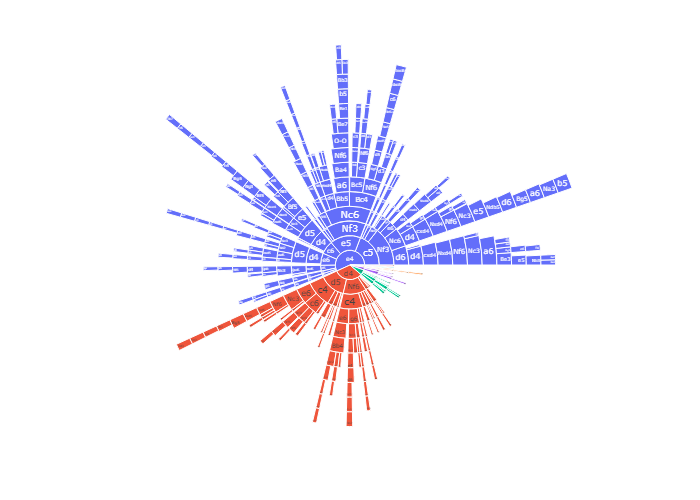

### Awards

Because winning isn’t everything; it’s the only thing :)

See the footnote for further details on selected awards.[^7]

| Award | Description | Winner | Details | Honourable mentions |
| --- | --- | --- | --- | --- |
| x | Archbishop of Accuracy | wookash_888 | 19.3 ACPL over 309 moves | FearlessKing64, DEJL |
| x | Awesome Alt | crouchbag, jamestgr, kostasvl | Played for 3 different teams | Aeraaa, antazhi8, brandonsato1, ChewieMarbles, exirk, FaKeOo, Felipekaox, FrugoFruit90, Giulio43532, grooble, ImproveToIM, iOnlyPractice, jbrooks95, joejoepie, juandeleon, LandyPJY, liboy, Lord_axe, M… |
| x | Bullet Boss | david252525 | 34 moves | NLance, Notsamire |
| x | David Award | liboy | Opponents' record: 20/27 | diegohdragon, AACtrl |
| x | Egalitarian Award | The Dude's Gambit | SD: 52.2 |  |
| x | Gambit Guru | Bjorgvin1 | 100% from 2 games | NA |
| x | Giri Award | alen111, drchessdad, FearlessKing64, Johnnyeccles01, Silkthewanderer, yeyq | 5 draws |  |
| x | Grischuk's Cousin | shakaali | Had 1m 21s left after 10 moves | pepepibote, CalculatedChess |
| x | Houdini Award | Janetheus |  | savvyd, Midnightokar |
| x | Intimate with Increment | AACtrl | 32.3% | k-night-moves, Sincraxis |

[output cut: 10 more lines]

### Detailed statistics

All the following tables are sortable and searchable.

#### Team statistics

| rank | Team | games | points | pts_nonforf | wins | draws | losses | players | avg_moves | ACPL | blunder_pc |
| --- | --- | --- | --- | --- | --- | --- | --- | --- | --- | --- | --- |
| 1 | No BS in Chess | 62 | 40 | 36 | 31 | 10 | 21 | 8 | 40.741935483871 | 42.3986539984165 | 3.95882818685669 |
| 2 | We Won This Season, BY A LOT! | 61 | 37 | 33 | 29 | 8 | 24 | 13 | 38.5409836065574 | 43.6341982135262 | 3.99829859634198 |
| 3 | The Dude's Gambit | 63 | 37.5 | 35 | 28 | 14 | 21 | 8 | 41.7301587301587 | 44.7999239254469 | 4.64054773678205 |
| 4 | PIPI in your pampers | 61 | 36 | 33 | 26 | 14 | 21 | 10 | 40.7868852459016 | 46.1889067524116 | 4.78295819935691 |
| 5 | Stress is Chessful | 62 | 35.5 | 33 | 27 | 12 | 23 | 9 | 39.9193548387097 | 45.1131313131313 | 4.36363636363636 |
| 6 | Pawn of the Dead | 60 | 37.5 | 35.5 | 28 | 15 | 17 | 12 | 38.5333333333333 | 47.030276816609 | 4.1522491349481 |
| 7 | Qf7# is still theory | 61 | 34.5 | 37.5 | 31 | 13 | 17 | 9 | 40.4754098360656 | 42.3539894694208 | 4.69825840421223 |
| 8 | true will never die! | 62 | 36.5 | 34.5 | 30 | 9 | 23 | 8 | 40.241935483871 | 42.0773547094188 | 3.687374749499 |
| 9 | Two Bishops One Square | 63 | 34.5 | 31.5 | 26 | 11 | 26 | 9 | 40.8095238095238 | 45.4667444574096 | 4.93971217425126 |
| 10 | Always Double Check | 62 | 34 | 39 | 33 | 12 | 17 | 8 | 41.3870967741936 | 47.0471551052221 | 4.71551052221356 |

[output cut: 30 more lines]

#### Best performances / highest accuracy

##### Best relative perfs

Shows players’ *relative* performance ratings: season performance rating minus initial rating.[^8]

*Includes all players with a positive relative performance rating over at least five games.*

| # | Player | Games | W | D | L | Initial | Perf | Diff. |
| --- | --- | --- | --- | --- | --- | --- | --- | --- |
| 1 | skyfaller1 | 8 | 7 | 1 | 0 | 2224 | 2646.875 | 422.875 |
| 2 | AsdrubalBarca | 8 | 6 | 2 | 0 | 1818 | 2198 | 380 |
| 3 | mapichar | 6 | 5 | 0 | 1 | 1426 | 1794 | 368 |
| 4 | Rehbein | 7 | 6 | 0 | 1 | 1582 | 1943.14285714286 | 361.142857142857 |
| 5 | Midnightokar | 8 | 6 | 2 | 0 | 1789 | 2147.625 | 358.625 |
| 6 | Khasi1596 | 5 | 4 | 1 | 0 | 1789 | 2133.2 | 344.2 |
| 7 | Janetheus | 8 | 7 | 0 | 1 | 1476 | 1816 | 340 |
| 8 | HighonPotnuse | 7 | 5 | 2 | 0 | 1514 | 1831.28571428571 | 317.285714285714 |
| 9 | Schackmacke | 8 | 6 | 2 | 0 | 2002 | 2316.875 | 314.875 |
| 10 | jitre | 6 | 5 | 0 | 1 | 1869 | 2172.66666666667 | 303.666666666667 |

[output cut: 147 more lines]

##### Lowest ACPL

*Includes the 100 players with the lowest ACPL (min. 100 moves played).*

| Rank | Player | Moves | ACPL |
| --- | --- | --- | --- |
| 1 | wookash_888 | 309 | 19.3042071197411 |
| 2 | FearlessKing64 | 308 | 21.2662337662338 |
| 3 | DEJL | 119 | 21.7058823529412 |
| 4 | god666 | 291 | 22.0103092783505 |
| 5 | Scrooge | 283 | 22.4487632508834 |
| 6 | OldOx | 326 | 23.180981595092 |
| 7 | ChristopherChabris | 209 | 24.1148325358852 |
| 8 | drchessdad | 338 | 24.8757396449704 |
| 9 | skyfaller1 | 429 | 25.5874125874126 |
| 10 | alen111 | 337 | 26.4836795252226 |

[output cut: 90 more lines]

#### Time spent / strongest opponents

##### Time spent

*Includes the 50 players who spent the most clock time over the season.*

| Rank | Player | Games | Total time spent |
| --- | --- | --- | --- |
| 1 | Sesquipedalism | 8 | 10h 40m 14s |
| 2 | adande1 | 9 | 10h 34m 55s |
| 3 | ATrueRavenclaw | 8 | 10h 22m 30s |
| 4 | JustinTanas | 8 | 10h 11m 38s |
| 5 | Lupo_Jones | 8 | 10h 10m 34s |
| 6 | Paulze2000 | 8 | 10h 5m 59s |
| 7 | lepertoe | 8 | 10h 1m 34s |
| 8 | penguinsr6 | 8 | 9h 56m 47s |
| 9 | texaspete09 | 8 | 9h 51m 46s |
| 10 | AACtrl | 8 | 9h 47m 13s |

[output cut: 40 more lines]

##### Time spent per move (after move 10)

*Includes everyone who played at least three games.*

| Rank | Player | Games | Moves | Time spent per move | Percentile |
| --- | --- | --- | --- | --- | --- |
| 1 | timsvlad | 4 | 56 | 3m 10.5s | 100 |
| 2 | ChristopherChabris | 6 | 149 | 2m 16.4s | 100 |
| 3 | rooktaker845 | 4 | 108 | 2m 14.3s | 100 |
| 4 | kaseyp | 7 | 206 | 2m 13.6s | 99 |
| 5 | IsaVulpes | 8 | 187 | 2m 10.4s | 99 |
| 6 | Charlesb198 | 7 | 183 | 2m 8.5s | 99 |
| 7 | CamLeslie | 7 | 144 | 2m 8.3s | 98 |
| 8 | primeideal | 8 | 188 | 2m 8.2s | 98 |
| 9 | passedpawn22 | 7 | 149 | 2m 6.5s | 98 |
| 10 | PetMarmoset | 7 | 139 | 2m 6.2s | 97 |

[output cut: 311 more lines]

##### Strength of schedule

These players faced the most in-form opponents across the season, when judged by their opponents’ collective score in all their other games.[^9]

*Includes all players who faced a collective group of opponents that played at least 15 (other) games across the season with a collective score above 50 per cent.*

| # | Player | Opp Games | Opp Pts | Opp % |
| --- | --- | --- | --- | --- |
| 1 | liboy | 27 | 20 | 74.0740740740741 |
| 2 | diegohdragon | 48 | 33 | 68.75 |
| 3 | AACtrl | 54 | 36.5 | 67.5925925925926 |
| 4 | yoitsyeboicat | 40 | 27 | 67.5 |
| 5 | jessehf | 41 | 27.5 | 67.0731707317073 |
| 6 | Sleepy_Gary | 47 | 31 | 65.9574468085106 |
| 7 | Ixitixl | 45 | 29.5 | 65.5555555555556 |
| 8 | H0tblackDesiat0 | 43 | 28 | 65.1162790697674 |
| 9 | rodeo | 47 | 30.5 | 64.8936170212766 |
| 10 | LucaGaglia73 | 37 | 24 | 64.8648648648649 |

[output cut: 150 more lines]

#### Comebacks and upsets

##### Comebacks

*Includes players with a positive average “comeback margin” that played at least three games.*[^10]

| Rank | Player | Average Comeback Margin | Total Comeback Margin |
| --- | --- | --- | --- |
| 1 | Janetheus | 1.40617768267136 | 11.2494214613709 |
| 2 | savvyd | 1.21405509091768 | 9.71244072734146 |
| 3 | Midnightokar | 1.16514227815178 | 9.32113822521421 |
| 4 | skyfaller1 | 1.1451264252089 | 9.1610114016712 |
| 5 | Fr4nco61 | 1.14264675721064 | 9.14117405768513 |
| 6 | Rehbein | 1.29796088521067 | 9.08572619647471 |
| 7 | HighonPotnuse | 1.2850799921846 | 8.99555994529218 |
| 8 | AACtrl | 1.11553323817414 | 8.92426590539314 |
| 9 | Schackmacke | 1.09789592773934 | 8.78316742191475 |
| 10 | Showboater | 1.09673697426151 | 8.77389579409206 |

[output cut: 309 more lines]

##### Biggest upsets

*Includes all players who defeated an opponent rated at least 50 points higher.*

| Rank | Player | Upset Margin |
| --- | --- | --- |
| 1 | electricfalcon | 316 |
| 2 | CalculatedChess | 281 |
| 3 | mahithas | 278 |
| 4 | lvdr | 277 |
| 5 | jsettle1 | 251 |
| 6 | LeChuckForPresident | 226 |
| 7 | mahithas | 225 |
| 8 | Patheticus | 221 |
| 9 | Eshpy | 204 |
| 10 | electricfalcon | 197 |

[output cut: 158 more lines]

##### Repeated upsets

Includes players who achieved multiple wins over opponents rated at least 50 points higher.

| Rank | Player | Total Upset Margin | Upsets | Avg Upset Margin | Biggest Margin |
| --- | --- | --- | --- | --- | --- |
| 1 | lvdr | 561 | 3 | 187 | 277 |
| 2 | electricfalcon | 513 | 2 | 256.5 | 316 |
| 3 | mahithas | 503 | 2 | 251.5 | 278 |
| 4 | CalculatedChess | 478 | 2 | 239 | 281 |
| 5 | jsettle1 | 407 | 2 | 203.5 | 251 |
| 6 | mapichar | 392 | 4 | 98 | 142 |
| 7 | masedog91 | 389 | 3 | 129.666666666667 | 153 |
| 8 | caodanny | 369 | 3 | 123 | 141 |
| 9 | rsava | 282 | 2 | 141 | 143 |
| 10 | Rehbein | 259 | 3 | 86.3333333333333 | 143 |

[output cut: 22 more lines]

#### Dawdlers and instant movers

##### Least time left after move 10

The players with the least time left after 10 moves…who still managed to win![^11]

| Rank | Player | Time left after 10 moves | Link |
| --- | --- | --- | --- |
| 1 | shakaali | 1m 21s | https://lichess.org/QfXdluhl#19 |
| 2 | pepepibote | 8m 5s | https://lichess.org/gDrzgLyS#19 |
| 3 | CalculatedChess | 8m 57s | https://lichess.org/ATLOIKZ8#19 |
| 4 | Sincraxis | 12m 4s | https://lichess.org/CAdZyHWa#19 |
| 5 | FaKeOo | 14m 54s | https://lichess.org/c8hTpwQB#20 |
| 6 | howtoparadox | 16m 51s | https://lichess.org/WDjq8qUY#20 |
| 7 | Tonuka | 16m 56s | https://lichess.org/inREyyO3#20 |
| 8 | Forhavu | 18m 17s | https://lichess.org/srjA3L6h#19 |
| 9 | AACtrl | 19m 56s | https://lichess.org/qAv3djhD#19 |
| 10 | AACtrl | 20m 18s | https://lichess.org/sTpxFufL#20 |

##### Instant moves

Players who made the most ‘instant’ moves over the season, taking less than 0.5 seconds (includes premoves).

*Includes players with more than five ‘instant’ moves.*

| Rank | Player | Instant moves |
| --- | --- | --- |
| 1 | david252525 | 34 |
| 2 | NLance | 23 |
| 3 | Notsamire | 20 |
| 4 | heroku | 19 |
| 4 | mathijshuis | 19 |
| 4 | shakaali | 19 |
| 5 | Lou-E | 18 |
| 5 | lvdr | 18 |
| 5 | Tsetsen | 18 |
| 6 | furrykef | 17 |

[output cut: 79 more lines]

#### Longest thinks, time trouble addicts, and lucky escapes

##### Longest thinks

The longest times spent on a single move.

*Top 100 shown.*

| # | Player | Time spent | Colour | Move | Link |
| --- | --- | --- | --- | --- | --- |
| 1 | kaseyp | 31m 20s | White | 17 | https://lichess.org/DhkvaOV9#33 |
| 2 | howtoparadox | 31m 18s | Black | 14 | https://lichess.org/2pMnhvIt#28 |
| 3 | Okoros | 28m 24s | White | 23 | https://lichess.org/GHh21j9V#45 |
| 4 | CamLeslie | 28m 22s | Black | 14 | https://lichess.org/PG9PGn8X#28 |
| 5 | Razorneck | 26m 11s | White | 16 | https://lichess.org/48Kz3nNe#31 |
| 6 | JustinTanas | 25m 57s | Black | 11 | https://lichess.org/PkxdRPvT#22 |
| 7 | Bjorgvin1 | 25m 55s | Black | 26 | https://lichess.org/DWOQQKwP#52 |
| 8 | phantom567459 | 25m 40s | White | 9 | https://lichess.org/ckHpcJQN#17 |
| 9 | bufferunderrun | 25m 11s | Black | 16 | https://lichess.org/DhkvaOV9#32 |
| 10 | bufferunderrun | 25m 9s | Black | 23 | https://lichess.org/Vp3KnPBj#46 |

[output cut: 90 more lines]

##### Time trouble addicts

Shows players by proportion of moves made in time trouble (defined as having less than a minute remaining on the clock).

*Includes everyone who played at least 100 moves over the season while making at least one move in time trouble.*

| # | Player | All moves | With < 1min left | Time Trouble % |
| --- | --- | --- | --- | --- |
| 1 | AACtrl | 337 | 109 | 0.323442136498516 |
| 2 | k-night-moves | 352 | 107 | 0.303977272727273 |
| 3 | Sincraxis | 343 | 94 | 0.274052478134111 |
| 4 | Hindemith | 279 | 74 | 0.265232974910394 |
| 5 | LeChuckForPresident | 109 | 26 | 0.238532110091743 |
| 6 | Marcos_Paulo | 251 | 53 | 0.211155378486056 |
| 7 | Alegre_River | 247 | 49 | 0.198380566801619 |
| 8 | texaspete09 | 382 | 75 | 0.196335078534031 |
| 9 | Sesquipedalism | 436 | 81 | 0.185779816513761 |
| 10 | frymealiver | 138 | 23 | 0.166666666666667 |

[output cut: 178 more lines]

##### Saved by the bell

Players who made moves with under 5 seconds left on their clock…and still won![^12]

| Player | Moves with under 5s left | Least time left | Link |
| --- | --- | --- | --- |
| k-night-moves | 5 | 1 | https://lichess.org/MmdoZYzB |
| k-night-moves | 4 | 4 | https://lichess.org/UQsdOj1d |
| LeChuckForPresident | 3 | 1 | https://lichess.org/945mNW7d |
| jwwells42 | 2 | 1 | https://lichess.org/Vv3p1ncA |
| mixxanber | 2 | 3 | https://lichess.org/1reijPTT |
| Sincraxis | 2 | 4 | https://lichess.org/o4sNSsO2 |
| AACtrl | 2 | 4 | https://lichess.org/sTpxFufL |
| Scarff | 1 | 3 | https://lichess.org/PJnrC2fr |
| AACtrl | 1 | 4 | https://lichess.org/qAv3djhD |
| AACtrl | 1 | 4 | https://lichess.org/adzHvtSQ |

[output cut: 2 more lines]

#### Misc. facts

##### Lesser spotted mates

A pawn gave checkmate in 3 games: https://lichess.org/NewGJPmm, https://lichess.org/pyN6o6eG, https://lichess.org/x1JZmo3k.

A knight gave checkmate in 8 games: https://lichess.org/wuDUrULq, https://lichess.org/GKaimDio, https://lichess.org/cGOGXdzd, https://lichess.org/FFIi8ft8, https://lichess.org/kvv1yqOX, https://lichess.org/qJQFLoI7, https://lichess.org/b5u4NI1B, https://lichess.org/yzLZlVSY.

##### Promotions

153 games had at least one promotion. 9 of these saw an under-promotion.

The most promotions seen in a game was 6: https://lichess.org/WHcvxwtF

##### Rollercoaster games

147 games featured significant winning chances for both sides (as identified by Lichess’s server analysis), comprising 11.9% of all games played.

##### Checks and captures

- Most consecutive checks: 23 (https://lichess.org/h5fZ1azk)
- Most consecutive captures: 11 (https://lichess.org/LWMRp70n)
- Latest-occurring first capture: ply 42 in https://lichess.org/Jp9lyV4w